# Demystifying R Survey Report

# About our Respondents

## Age

The graph belows shows the age of respondents broken into three groups.

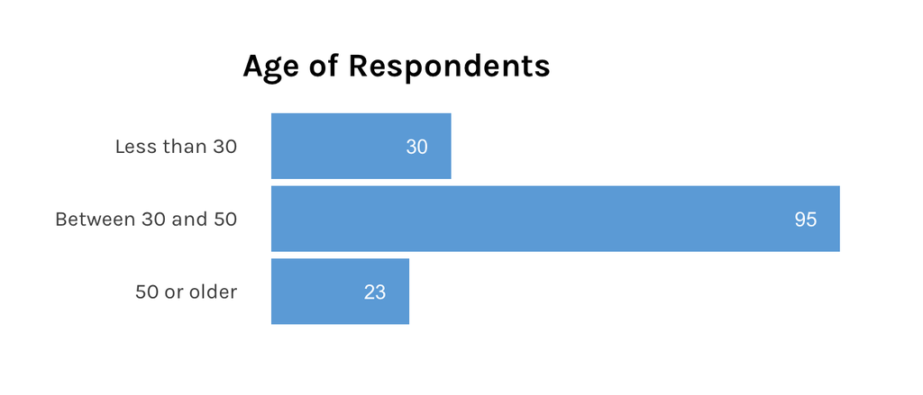

## Education

The education levels of respondents are below.

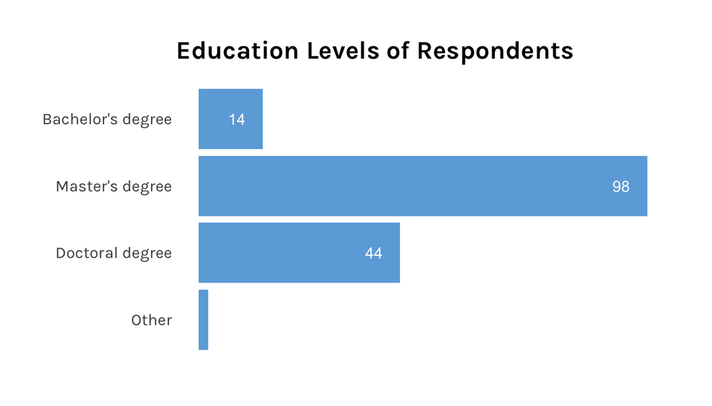

## Locations

Respondents listed the location of their primary residence. The map below shows their locations.

[interactive chart not shown]

## Gender

Respondents were asked to list their gender, in whatever form they choose to identify it.

The original responses are below.

| Gender (Original Response) |
| --- |
| Boy |
| Boy |
| Boy |
| Queer |
| Female |
| Female |
| female |
| Female |
| female |
| Female |

[output cut: 142 more lines]

The table below shows a summary of all responses.

| Gender (Original Response) | Number of Responses |
| --- | --- |
| Boy | 3 |
| Cis-woman | 1 |
| f | 3 |
| F | 6 |
| Fem | 1 |
| female | 34 |
| Female | 67 |
| FEMALE | 1 |
| female (cis gendered) | 1 |
| Femenine | 1 |

[output cut: 10 more lines]

We then used the [gendercodeR package](https://github.com/ropenscilabs/gendercoder) to recode responses. The table below shows the original responses and the recoded responses.

| Original Responses | Recoded Gender |
| --- | --- |
| Boy | Male |
| Boy | Male |
| Boy | Male |
| Queer | Unable to recode |
| Female | Female |
| Female | Female |
| female | Female |
| Female | Female |
| female | Female |
| Female | Female |

[output cut: 142 more lines]

We can then summarize the recoded responses, which we do in the following table.

| Recoded Gender | Number of Responses |
| --- | --- |
| Cis Female | 1 |
| Female | 114 |
| Male | 32 |
| Transgender Male | 1 |
| Unable to recode | 4 |

# Familiarity with R

On a 5-point scale, respondents listed their level of familiarity with R as 1.9. The figure below shows familiarity broken down by education level.

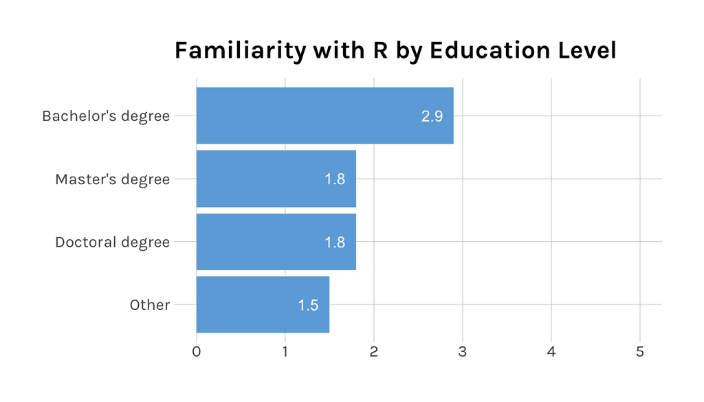

# Interest in Learning R

On a 5-point scale, respondents listed their level of interest in learning R as 4.3.

We can do a similar breakdown, but adding age. With one line of code, we can make small multiples.

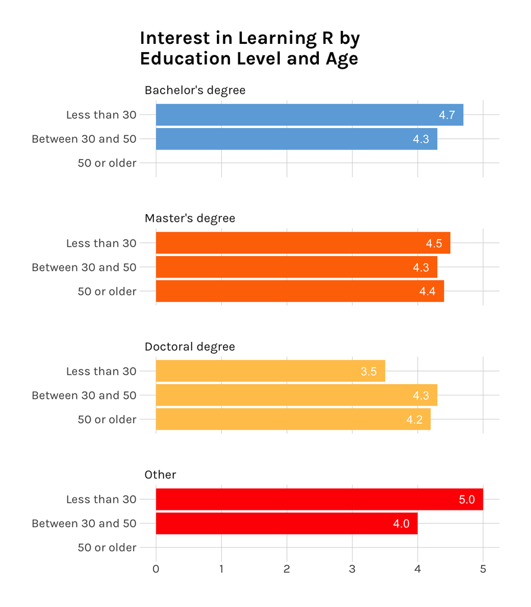